# Homework Assignment 4

Brendan Smith

March 3, 2016

**Objective Statement:** The prupose of this lab is to determine if the linear models we are developing can adequately characterize the biomass found in the studied habitats. Further, we must compare sites and genera, determining which vary more than others. We are building upon previous labs, and developing a full linear model that relates tree height as a function of DBH and site or genus. A new report will be created that shows the model results for the height as a function of DBH and a factor, being site or genus.

```r
#Concatenate ProjCode and Plot.Name using the paste() function, typecast as a factor, then place these factors in rip$projplot
rip$projplot <- as.factor(paste(rip$ProjCode,rip$Plot.Name))

#use tapply() to cycle through each project plot and generate stats
#where ‘htcm’ is height in cm
ripsum <- data.frame(cbind(tapply(rip$htcm,rip$projplot,mean),tapply(rip$htcm,rip$projplot,sd),tapply(rip$htcm,rip$projplot,length)))
#add column names
#(height mean, height standard deviation, number of plots)
colnames(ripsum) <- c("htcmmn","htcmsd","plot.n")
#add a projplot column (from row names) to ripsum
ripsum$projplot <- as.factor(rownames(ripsum))
```

```r
#subset for plots with more than one measurement
ripsum <- ripsum[ripsum$plot.n > 1,]
#Add a proj column and populate with the first five letters of projplot (the ProjCode) via the substr() function. Then typecast to factor
ripsum$proj <- as.factor(substr(ripsum$projplot,1,5))
```

We compare the `for` loop operation to the list apply (`lapply`) in order to demonstrate that although the functions have similar outcomes, the list apply is more efficient for evaluating an array of values simultaneously.

```r
#create list of project sites
projlevels <- levels(ripsum$proj) #compare a ‘for’ loop of summary
for (p in 1:length(projlevels)) print(summary(ripsum[ripsum$proj == projlevels[p],]))
```

```
##      htcmmn           htcmsd            plot.n          projplot
##  Min.   : 204.1   Min.   :  42.43   Min.   :  2.00   COSRP 1: 1
##  1st Qu.: 769.0   1st Qu.: 277.50   1st Qu.:  9.50   COSRP 2: 1
##  Median :1000.0   Median : 436.05   Median : 18.00   COSRP 3: 1
##  Mean   :1042.3   Mean   : 459.94   Mean   : 25.23   COSRP 4: 1
##  3rd Qu.:1269.2   3rd Qu.: 624.36   3rd Qu.: 32.50   COSRP 5: 1
##  Max.   :3330.0   Max.   :1031.60   Max.   :111.00   COSRP 6: 1
##                                                      (Other):81
##     proj
##  COSRP:87
##  HEROW: 0
##  NAPSO: 0
##  SACTO: 0
##
##
##
##      htcmmn           htcmsd            plot.n             projplot
##  Min.   : 421.3   Min.   :  68.18   Min.   : 8.00   HEROW RIP01:1
##  1st Qu.: 505.6   1st Qu.: 141.83   1st Qu.:11.50   HEROW RIP02:1
##  Median : 883.0   Median : 218.21   Median :27.00   HEROW RIP03:1
##  Mean   : 978.1   Mean   : 401.83   Mean   :39.14   HEROW RIP04:1
##  3rd Qu.:1332.6   3rd Qu.: 546.12   3rd Qu.:62.00   HEROW RIP05:1
##  Max.   :1866.0   Max.   :1150.50   Max.   :92.00   HEROW RIP06:1
##                                                     (Other)    :1
##     proj
##  COSRP:0
##  HEROW:7
##  NAPSO:0
##  SACTO:0
##
##
##
##      htcmmn           htcmsd          plot.n                   projplot
##  Min.   : 671.0   Min.   :171.6   Min.   : 4.00   NAPSO Crp2013_509:1
##  1st Qu.: 745.4   1st Qu.:472.4   1st Qu.: 6.75   NAPSO S02013_200 :1
##  Median : 814.6   Median :556.3   Median :17.50   NAPSO S02013_202 :1
##  Mean   : 977.8   Mean   :538.2   Mean   :24.00   NAPSO S02013_203 :1
##  3rd Qu.:1016.4   3rd Qu.:649.9   3rd Qu.:29.25   NAPSO S02013_207 :1
##  Max.   :1888.3   Max.   :819.5   Max.   :81.00   NAPSO S02013_211 :1
##                                                   (Other)          :2
```

[output cut: 9 more lines]

```
##  Min.   : 443.2   Min.   :  93.04   Min.   : 2.00   SACTO EW2013_100: 1
##  1st Qu.: 678.7   1st Qu.: 254.57   1st Qu.: 4.00   SACTO EW2013_101: 1
##  Median : 977.0   Median : 584.23   Median : 7.00   SACTO EW2013_102: 1
##  Mean   :1071.0   Mean   : 623.96   Mean   :11.82   SACTO EW2013_103: 1
##  3rd Qu.:1256.6   3rd Qu.: 882.65   3rd Qu.:17.00   SACTO EW2013_106: 1
##  Max.   :2532.9   Max.   :1668.77   Max.   :59.00   SACTO EW2013_110: 1
##                                                     (Other)         :38
##     proj
##  COSRP: 0
##  HEROW: 0
##  NAPSO: 0
##  SACTO:44
##
##
##
```

```r
#with a summary using lapply() (known as list apply)
lapply(projlevels, function(x) summary(ripsum[ripsum$proj == x,]))
```

```
## [[1]]
##      htcmmn           htcmsd            plot.n          projplot
##  Min.   : 204.1   Min.   :  42.43   Min.   :  2.00   COSRP 1: 1
##  1st Qu.: 769.0   1st Qu.: 277.50   1st Qu.:  9.50   COSRP 2: 1
##  Median :1000.0   Median : 436.05   Median : 18.00   COSRP 3: 1
##  Mean   :1042.3   Mean   : 459.94   Mean   : 25.23   COSRP 4: 1
##  3rd Qu.:1269.2   3rd Qu.: 624.36   3rd Qu.: 32.50   COSRP 5: 1
##  Max.   :3330.0   Max.   :1031.60   Max.   :111.00   COSRP 6: 1
##                                                      (Other):81
##     proj
##  COSRP:87
##  HEROW: 0
##  NAPSO: 0
##  SACTO: 0
##
##
##
##
## [[2]]
##      htcmmn           htcmsd            plot.n             projplot
##  Min.   : 421.3   Min.   :  68.18   Min.   : 8.00   HEROW RIP01:1
##  1st Qu.: 505.6   1st Qu.: 141.83   1st Qu.:11.50   HEROW RIP02:1
##  Median : 883.0   Median : 218.21   Median :27.00   HEROW RIP03:1
##  Mean   : 978.1   Mean   : 401.83   Mean   :39.14   HEROW RIP04:1
##  3rd Qu.:1332.6   3rd Qu.: 546.12   3rd Qu.:62.00   HEROW RIP05:1
##  Max.   :1866.0   Max.   :1150.50   Max.   :92.00   HEROW RIP06:1
##                                                     (Other)    :1
##     proj
##  COSRP:0
##  HEROW:7
##  NAPSO:0
##  SACTO:0
##
##
##
##
## [[3]]
##      htcmmn           htcmsd          plot.n                   projplot
##  Min.   : 671.0   Min.   :171.6   Min.   : 4.00   NAPSO Crp2013_509:1
##  1st Qu.: 745.4   1st Qu.:472.4   1st Qu.: 6.75   NAPSO S02013_200 :1
```

[output cut: 16 more lines]

```
##  Min.   : 443.2   Min.   :  93.04   Min.   : 2.00   SACTO EW2013_100: 1
##  1st Qu.: 678.7   1st Qu.: 254.57   1st Qu.: 4.00   SACTO EW2013_101: 1
##  Median : 977.0   Median : 584.23   Median : 7.00   SACTO EW2013_102: 1
##  Mean   :1071.0   Mean   : 623.96   Mean   :11.82   SACTO EW2013_103: 1
##  3rd Qu.:1256.6   3rd Qu.: 882.65   3rd Qu.:17.00   SACTO EW2013_106: 1
##  Max.   :2532.9   Max.   :1668.77   Max.   :59.00   SACTO EW2013_110: 1
##                                                     (Other)         :38
##     proj
##  COSRP: 0
##  HEROW: 0
##  NAPSO: 0
##  SACTO:44
##
##
##
```

It can be seen that while the outcome is the same, the setup and application of the for loop is somewhat inefficient in that we must manually indicate the start and stop indeces in order to iterate through the entire array/vector individually with the `for` loop, whereas with the list apply, all elements are evaluated by the function automatically.

We then use `lapply` to randomly select six sample plot summaries from each project site. This is done by by first introducing a variable that is set to the integer 6, the number of samples desired. The function `sample` is then used to output the desired number of samples (6) randomly from each project site. To execute this for all project sites, the `lapply` function is utilized. These values are stored and combined by row using the `rbind()` function along with `do.call()`. Finally, the summary is output.

```r
nsamples <- 6 #Set the number of samples
ripres <- lapply(projlevels, function(x) ripsum[which(ripsum$proj == x),][sample(nrow(ripsum[which(ripsum$proj == x),]),nsamples),])
# combine samples by row using rbind()
# and by calling ripres lapply function from do.call()
ripsample <- do.call(rbind,ripres)
summary(ripsample$proj)
```

```
## COSRP HEROW NAPSO SACTO
##     6     6     6     6
```

The coefficient of variation (CV) then added to the summary table by calculating the CV by means of the `with()` function. The `with()` function evaluates an `R` expression (second input term) of the input data (first term). In this case, we are evaluating the coefficient of variation, which is the standard deviation divided by the mean. This value is then stored into our dataframe.

```r
#calculate CV using with(data,calc)
ripsample$cv <- with(ripsample, htcmsd / htcmmn)
```

```r
rip.proj.cv.aov = aov(cv~proj,data=ripsample)
summary(rip.proj.cv.aov)
```

```
##             Df Sum Sq Mean Sq F value Pr(>F)
## proj         3 0.3363 0.11209   1.916   0.16
## Residuals   20 1.1701 0.05851
```

```r
#compare it against
summary.lm(rip.proj.cv.aov)
```

```
##
## Call:
## aov(formula = cv ~ proj, data = ripsample)
##
## Residuals:
##      Min       1Q   Median       3Q      Max
## -0.33132 -0.18472  0.01277  0.13767  0.55502
##
## Coefficients:
##             Estimate Std. Error t value Pr(>|t|)
## (Intercept)  0.39975    0.09875   4.048 0.000628 ***
## projHEROW   -0.04671    0.13965  -0.334 0.741519
## projNAPSO    0.15826    0.13965   1.133 0.270519
## projSACTO    0.24684    0.13965   1.768 0.092391 .
## ---
## Signif. codes:  0 '***' 0.001 '**' 0.01 '*' 0.05 '.' 0.1 ' ' 1
##
## Residual standard error: 0.2419 on 20 degrees of freedom
## Multiple R-squared:  0.2232, Adjusted R-squared:  0.1067
## F-statistic: 1.916 on 3 and 20 DF,  p-value: 0.1595
```

The main differences between the summary of the ANOVA results and the summary of the linear model of the ANOVA is that the lm version yields information regarding the individual project sites and the residuals, whereas the summary of the ANOVA yields information regarding all project sites and residuals, limited to DOF, sum of squares, mean squared, F value and probability.

A Tukey test is performed to check for significant differences between sites, and print out the results. We can see from the print out of the Tukey test and the plot that there is not a significant difference between sites.

```r
rip.aov.hsd <- TukeyHSD(rip.proj.cv.aov)
rip.aov.hsd
```

```
##   Tukey multiple comparisons of means
##     95% family-wise confidence level
##
## Fit: aov(formula = cv ~ proj, data = ripsample)
##
## $proj
##                    diff         lwr       upr     p adj
## HEROW-COSRP -0.04670626 -0.43757576 0.3441632 0.9867173
## NAPSO-COSRP  0.15825534 -0.23261416 0.5491248 0.6739271
## SACTO-COSRP  0.24683773 -0.14403178 0.6377072 0.3173019
## NAPSO-HEROW  0.20496160 -0.18590791 0.5958311 0.4743955
## SACTO-HEROW  0.29354398 -0.09732552 0.6844135 0.1865286
## SACTO-NAPSO  0.08858239 -0.30228712 0.4794519 0.9197064
```

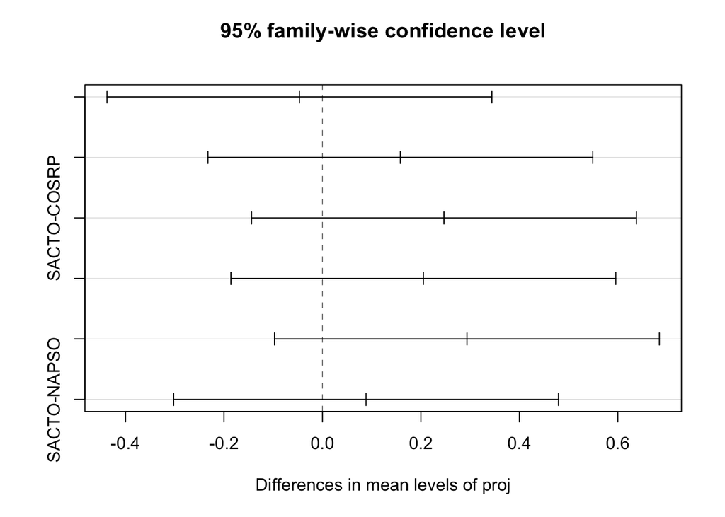

```r
plot(rip.aov.hsd)
```

```r
#ancovaplot(rip$htcm~rip$Woody_DBH_cm*rip$Genus,data=survey)
```

**Results:**

Step 1 - Using ANOVA for future model selection

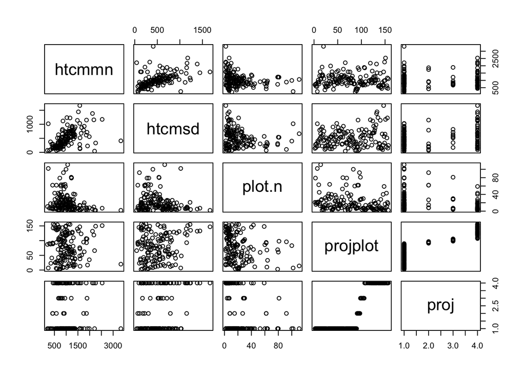

```r
plot(ripsum)
```